# Bootstrap et LESS

30/01/2018

## Plan du cours

1. Qu'est ce qu'un framework (front end/css)?
2. Bootstrap
3. LESS

## Qu'est ce qu'un framework?

### Framework ou cadriciel :

> " Un ensemble cohérent de composants logiciels structurels, qui sert à créer les fondations ainsi que les grandes lignes de tout ou d’une partie d'un logiciel " *[Wikipedia](https://fr.wikipedia.org/wiki/Framework)*

Un framework se différencie d'une bibliothèque par sa nature générique

## Qu'est ce qu'un framework?

### Un framework permet de

- Structurer l'architecture logicielle
  - Pattern (patron de conception) MVC (Modèle Vue Controleur), interactions avec le SGBD, …
- Faciliter le développement de tâches récurrentes
  - Tâches récurrentes pré programmées
- Rendre générique une application
  - Spécialisation de classes du framework

## Framework front end

Côté client: interface, gestion des interactions (HTML, CSS, JS)

- La base : typographie, aspects généraux
- le layout : zones principales de l'architecture de la page (en-tête, menu, contenu principal, pied de page) -> facilement manipulable
- les modules : objets composant les zones de layout (liste, bouton, formulaire, slider…) -> couvrant les besoins courants
- les états des modules : montré/ caché, hover, actif/inactif, focus… -> standards
- comportements interactifs : menus animés, carrousel, onglets interactifs, verification de formulaire -> gestion facilitée

## Responsive design

(ou conception de sites web adaptifs) :

- L'affichage s'adapte à la taille de l'écran (répond aux changement de largeur et de hauteur de la page) -> paramétrable
- Différent de *adaptive design* : l'affichage du contenu et parfois le contenu lui même change en fonction de l'appareil utilisé (ex: plus de photos sur smartphones, reduction des menus …)

## Bootstrap

[figure not shown]

Créé par Twitter (2011). Framework CSS open-source permettant de faciliter la création de page HTML **responsive**

- Principe de grille responsive, styles CSS prédéfinis pour tous les éléments HTML
  - Faciliter l'organisation et l'aspect des pages
- Composant JS prédéfinis (liste déroulantes dynamiques, carrousel)
- Police avec set d'icones (vectorielles)
- Multi navigateur (Desktop et mobile) -> apparence uniforme et standardisation des éléments graphiques

Documentation v3 : https://getbootstrap.com/docs/3.3/

## Bootstrap - Exemple de thème

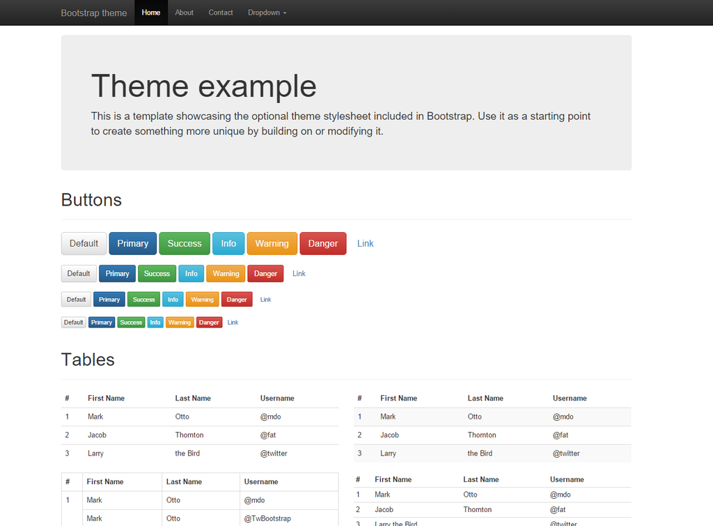

https://getbootstrap.com/examples/theme/

## Bootstrap - Fonctionnement

*Remarque : ce cours s'appuie sur la version 3 de Bootstrap*

Utilisation d'une série de feuilles de styles **LESS** (*à partir de la version 4 SASS*) qui implémentent différents composants :

- Une feuille de style principale englobe les feuilles de styles des composants

- Quatre variations (différents formats et supports) :
  - téléphones (portrait et paysage),
  - tablette et PC (haute et basse résolution).

## Bootstrap - Système de grille

Principe : Système de grille à 12 colonnes et des lignes. Dans `col-md-*` l'étoile indique le nombre de colonnes que prend le bloc dans la page.

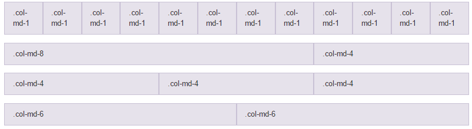

```html
<!--HTML-->
<taghtml class="col-md-*">contenu</taghtml>
```

## Bootstrap - Système adaptatif

Quatre classes pour s'adapter à tout les appareils. Dans `col-*-5` l'étoile indique la taille d'appareil. Permet de créer des layouts adaptés à chaque medium, plus flexible.

- `xs` (for phones - screens less than 768px wide)
- `sm` (for tablets - screens equal to or greater than 768px wide)
- `md` (for small laptops - screens equal to or greater than 992px wide)
- `lg` (for laptops and desktops - screens equal to or greater than 1200px wide)

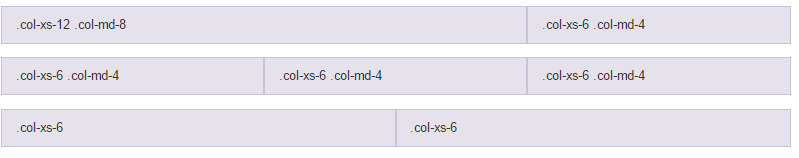

```html
<!--HTML-->
<taghtml class="col-*-5">contenu</taghtml>
```

## Bootstrap - Comportement des composants responsive

Comportements déjà implémentés grâce aux "responsives breakpoints"

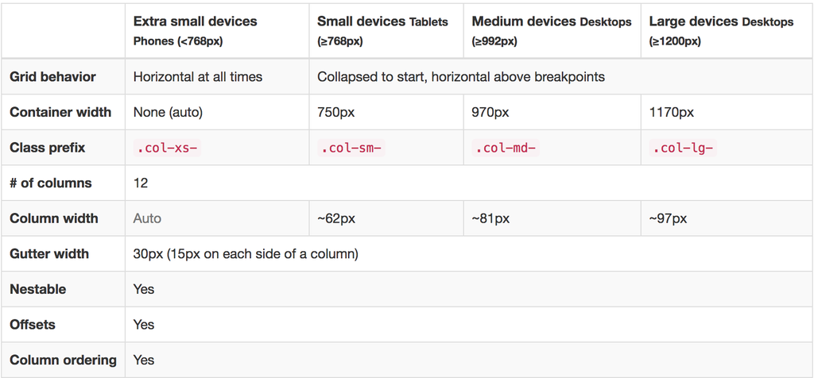

<sub><sup>* gutter = goutière : espace entre les composants</sup></sub>

## Bootstrap - Autres notions

### Containers

Deux types de containers dans bootstrap:

- La classe `.container` fournit un container adaptatif de taille fixe
- La classe `.container-fluid` fournit un container qui prend toute la largeur du viewport (étendu)

La classe `row` permet wrapper des colonnes ensemble (une ligne dans la grille).

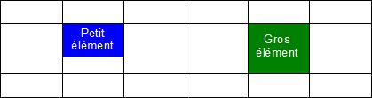

source :[OpenClassRoom](https://openclassrooms.com/courses/prenez-en-main-bootstrap/une-grille)

## Bootstrap - Exemple

```html
<div class="jumbotron">
  <h1>Jumbotron heading</h1>
  <p class="lead">Cras justo odio, dapibus ac facilisis in, egestas eget quam. Fusce dapibus, tellus ac cursus commodo, tortor mauris condimentum nibh, ut fermentum massa justo sit amet risus.</p>
  <p><a class="btn btn-lg btn-success" href="#" role="button">Sign up today</a></p>
</div>

<div class="row marketing">
  <div class="col-lg-6">
    <h4>Subheading</h4>
    <p>Donec id elit non mi porta gravida at eget metus. Maecenas faucibus mollis interdum.</p>

    <h4>Subheading</h4>
    <p>Morbi leo risus, porta ac consectetur ac, vestibulum at eros. Cras mattis consectetur purus sit amet fermentum.</p>

    <h4>Subheading</h4>
    <p>Maecenas sed diam eget risus varius blandit sit amet non magna.</p>
  </div>

  <div class="col-lg-6">
    <h4>Subheading</h4>
    <p>Donec id elit non mi porta gravida at eget metus. Maecenas faucibus mollis interdum.</p>

    <h4>Subheading</h4>
    <p>Morbi leo risus, porta ac consectetur ac, vestibulum at eros. Cras mattis consectetur purus sit amet fermentum.</p>

    <h4>Subheading</h4>
    <p>Maecenas sed diam eget risus varius blandit sit amet non magna.</p>
  </div>
</div>
```

## Bootstrap - Exemple

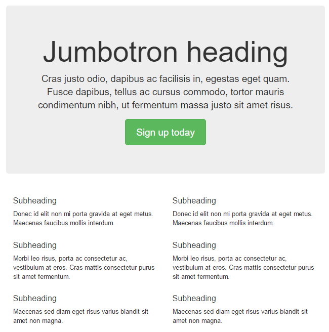

## Bootstrap - Mise en place

```html
<!DOCTYPE html>
<html lang="en">
  <head>
    <meta charset="utf-8">
    <meta http-equiv="X-UA-Compatible" content="IE=edge">
    <meta name="viewport" content="width=device-width, initial-scale=1">
    <!-- The above 3 meta tags *must* come first in the head; any other head content must come *after* these tags -->
    <meta name="description" content="">
    <meta name="author" content="">
    <link rel="icon" href="../../favicon.ico">

    <title>My first bootstrap page</title>

    <!-- Latest compiled and minified CSS -->
    <link rel="stylesheet" href="https://maxcdn.bootstrapcdn.com/bootstrap/3.3.7/css/bootstrap.min.css">
    <!-- jQuery library -->
    <script src="https://ajax.googleapis.com/ajax/libs/jquery/3.3.1/jquery.min.js"></script>
    <!-- Latest compiled JavaScript -->
    <script src="https://maxcdn.bootstrapcdn.com/bootstrap/3.3.7/js/bootstrap.min.js"></script>
  </head>
  <body>
    <h1>Hello World !</h1>

  </body>
</html>
```

## Bootstrap - Quelques composants (1/3)

Dropdown Menu

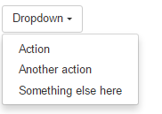

```html
<div class="dropdown">
  <button class="btn btn-default dropdown-toggle" type="button" id="dropdownMenu1" data-toggle="dropdown" aria-haspopup="true" aria-expanded="true">
    Dropdown
    <span class="caret"></span>
  </button>
  <ul class="dropdown-menu" aria-labelledby="dropdownMenu1">
    <li><a href="#">Action</a></li>
    <li><a href="#">Another action</a></li>
    <li><a href="#">Something else here</a></li>
    <li role="separator" class="divider"></li>
    <li><a href="#">Separated link</a></li>
  </ul>
</div>
```

## Bootstrap - Quelques composants (2/3)

Jumbotron

[figure not shown]

```html
      <div class="jumbotron">
        <h1>Jumbotron heading</h1>
        <p class="lead">Cras justo odio, dapibus ac facilisis in, egestas eget quam. Fusce dapibus, tellus ac cursus commodo, tortor mauris condimentum nibh, ut fermentum massa justo sit amet risus.</p>
        <p><a class="btn btn-lg btn-success" href="#" role="button">Sign up today</a></p>
      </div>
```